# Les fonctions utiles pour le TP 2

Pour avoir des informations plus précises sur les fonctions, reportez vous à l’aide intégrée de RStudio en saisissant directment le nom de la fonction dans la barre de recherche de l’onglet *Help* de l’écran en bas à droite.

# Des fonctions de base

**Instalation et chargement des packages :**

Pour charger un package il faut utiliser la fonction *library()*. Si un package n’est pas installé vous devez l’intaller en utilisant la fonction *install.packages()* ou les boutons de l’interface.

**Exemple :**

```r
library(dplyr)
```

**read.csv() et read.csv2():** Pour importer des fichiers .csv

La différence entre les deux fonctions, c’est les parmètres par défault.

Cette fonction a beaucoup de paramètres, on utilise souvent :

- sep(par exemple “.” ou “,”)
- encoding=“utf8” ou “latin1” (pour éviter les sympboles bizarres)
- dec = “.” ou “,”

En pratique, on utilise les fonctions en laissant les paramètres par default puis on ajuste au besoin

**Exemple :**

```r
titanic_client1 <- read.csv("titanic_client1.csv")
```

**read_excel() :** Pour lire des fichiers excel

Il faut renseigner le chemin du fichier et la feuille du fichier que l’on souhaite charger

**Exemple :**

```r
library(readxl)
zozo <- read_excel("titanic_place.xlsx", sheet = "titanicplace")
```

**rbind() :** Pour concaténer deux tables

**Exemple :**

```r
df1 <- data_frame(position = 1:5, lettre = LETTERS[1:5])
df2 <- data_frame(position = 6:26, lettre = LETTERS[6:26])

alphabet <- rbind(df1 ,df2)
alphabet
```

```
## # A tibble: 26 × 2
##    position lettre
##       <int> <chr>
##  1        1 A
##  2        2 B
##  3        3 C
##  4        4 D
##  5        5 E
##  6        6 F
##  7        7 G
##  8        8 H
##  9        9 I
## 10       10 J
## # … with 16 more rows
```

**head(x, n) et tail(x, n) :** Les n premières ou dernières observation de la table x

**Exemple :**

```r
#Les trois premières lettres de l'alphabet
head(letters,3)
```

```
## [1] "a" "b" "c"
```

```r
#Les quatre dernières
tail(letters, 4)
```

```
## [1] "w" "x" "y" "z"
```

**str(x) et summary(x) :** Des informations générales sur les variables de la table x

**nchar() :** Renvoit le nombre de caractères de toutes les chaines du vecteur

**Exemple :**

```r
nchar( c("dfdffd","fd","yyryryryr","abc"))
```

```
## [1] 6 2 9 3
```

**nrow(x) et ncol(x) :** Nombre de ligne ou de colonnes de la table x

**cbind(v1,v2) :** Pour mettre cote à cote les vecteurs ou les tables v1 et v2

**Exemple :**

```r
tab <- cbind(1:12, head(letters,12))
nrow(tab)
```

```
## [1] 12
```

```r
ncol(tab)
```

```
## [1] 2
```

**paste0() :** Pour coller des chaines de caractères

**Exemple :**

```r
paste0("a","b","c","...etc")
```

```
## [1] "abc...etc"
```

```r
# On peut l'appliquer à un vecteur, pour cela il faut renseigner le séparateur dans le paramètre collapse

paste0(letters,collapse = "")
```

```
## [1] "abcdefghijklmnopqrstuvwxyz"
```

**duplicated() :** Pour repérer des doublons, retourne un vecteur de *TRUE* et *FALSE*

On peut l’appliquer à une variable ou un ensemble de variable

**Exemple :**

```r
var <- c(1,1,2,2,3,4,5,5,5)
duplicated(var)
```

```
## [1] FALSE  TRUE FALSE  TRUE FALSE FALSE FALSE  TRUE  TRUE
```

```r
var[!duplicated(var)]
```

```
## [1] 1 2 3 4 5
```

```r
zozo <- rbind(df1,df1)
duplicated(zozo)
```

```
##  [1] FALSE FALSE FALSE FALSE FALSE  TRUE  TRUE  TRUE  TRUE  TRUE
```

```r
zozo[!duplicated(zozo),]
```

```
## # A tibble: 5 × 2
##   position lettre
##      <int> <chr>
## 1        1 A
## 2        2 B
## 3        3 C
## 4        4 D
## 5        5 E
```

```r
#ou
#avec la syntaxe dplyr et . qui renvoit à zozo
zozo %>% filter(!duplicated(.))
```

```
## # A tibble: 5 × 2
##   position lettre
##      <int> <chr>
## 1        1 A
## 2        2 B
## 3        3 C
## 4        4 D
## 5        5 E
```

**is.na() :** Retourne un vecteur de *TRUE* et *FALSE*

**Exemple :**

```r
v <- c(2,12,NA,3)
is.na(v)
```

```
## [1] FALSE FALSE  TRUE FALSE
```

**Utilisation des booléen et des sommes :**

Les booléens s’additionnent, les TRUE valent 1 et les FALSE 0, c’est très pratique !

**Exemples :**

```r
TRUE + TRUE + FALSE
```

```
## [1] 2
```

```r
sum(T,F,T,T,T,F)
```

```
## [1] 4
```

```r
sum(is.na(v))
```

```
## [1] 1
```

```r
sum(var==1)
```

```
## [1] 2
```

**quantile() :** Retourne des quantile d’un vecteur numérique

**Exemple :**

```r
v <- c(1:120)
quantile(v, c(0.2,0.4,0.6,0.6))
```

```
##  20%  40%  60%  60%
## 24.8 48.6 72.4 72.4
```

# Syntaxe et fonctions dplyr

**Mutate() :** Calculer une nouvelle variable

**Select() :** Sélectionner des colonnes

**Exemple :**

```r
library(dplyr)

exempleMut <- mtcars %>%
                mutate(somme = mpg + cyl) %>%
                    select(mpg,cyl,somme)
exempleMut %>% head()
```

```
##                    mpg cyl somme
## Mazda RX4         21.0   6  27.0
## Mazda RX4 Wag     21.0   6  27.0
## Datsun 710        22.8   4  26.8
## Hornet 4 Drive    21.4   6  27.4
## Hornet Sportabout 18.7   8  26.7
## Valiant           18.1   6  24.1
```

**filter() :** Pour filter certaines observations en fonction d’une condition

```r
cars %>% filter(speed < 11)
```

```
##   speed dist
## 1     4    2
## 2     4   10
## 3     7    4
## 4     7   22
## 5     8   16
## 6     9   10
## 7    10   18
## 8    10   26
## 9    10   34
```

**summarise() :** Pour faire des calculs sur toutes la table où des groupes de la table.

**Les principaux opérateur:**

- *n()* nombre de lignes
- *mean(var)* moyenne
- *weighted.mean(variable, pondération)* moyenne pondérée
- *max(var) min(var)* maximum et minimum
- *var(var)* variance empirique sans biais
- *sd(var)* ecart type
- *sum(var)* somme

**Exemple :**

```r
# Moyenne de la variable disp et nombre de d'observation de la table mtcars
mtcars %>%
  summarise(moyenne = mean(disp), effectif = n())
```

```
##    moyenne effectif
## 1 230.7219       32
```

*summarise()* est souvent utilisée avec la fonction *group_by()* pour faire des calculs par groupe.

```r
# Moyenne de la variable disp et nombre de d'observation pour chaque modalité de la variable cyl de la table mtcars
mtcars %>%
  group_by(cyl) %>%
  summarise(moyenneCyl = mean(disp), effectifCyl = n())
```

```
## # A tibble: 3 × 3
##     cyl moyenneCyl effectifCyl
##   <dbl>      <dbl>       <int>
## 1     4       105.          11
## 2     6       183.           7
## 3     8       353.          14
```

**slice_max() :** Retourne la ligne correspondant à l’observation où *variable* est maximale

**Exemple :**

```r
# Moyenne de la variable disp et nombre de d'observation de la table mtcars
mtcars %>%
  slice_max(disp)
```

```
##                     mpg cyl disp  hp drat   wt  qsec vs am gear carb
## Cadillac Fleetwood 10.4   8  472 205 2.93 5.25 17.98  0  0    3    4
```

**case_when() :** Pour faire des classes

**Exemple**

```r
titanic_client1 <- titanic_client1 %>%
  mutate(ageTranche = case_when(
    Age < 18 ~ "[0;24[",
    Age < 26 ~ "[24;45[",
    Age < 55 ~ "[46;80[",
    .default = "[80 et plus["
))
```

**arrange() :** Pour ordonner les valeurs

**Exemple :**

```r
#Ordonner la table dfen ordre décroissant
titanic_client1  %>% arrange(desc(Age)) %>% head()
```

```
##      id Civilite Age EpouseFrat ParentsEnf   ageTranche
## 1  id15       Mr  80          0          0 [80 et plus[
## 2  id62      Mrs  76          1          0 [80 et plus[
## 3  id10       Mr  71          0          0 [80 et plus[
## 4 id136       Mr  71          0          0 [80 et plus[
## 5  id82           70          1          1 [80 et plus[
## 6 id286       Mr  67          1          0 [80 et plus[
```

```r
#Ordonner la table df en ordre croissant
titanic_client1  %>% arrange(Age) %>% head()
```

```
##      id Civilite     Age EpouseFrat ParentsEnf ageTranche
## 1   id2   Master  0.9167          1          2     [0;24[
## 2   id3     Miss  2.0000          1          2     [0;24[
## 3  id95   Master  4.0000          0          2     [0;24[
## 4 id274   Master  6.0000          0          2     [0;24[
## 5  id55   Master 11.0000          1          2     [0;24[
## 6 id250   Master 13.0000          2          2     [0;24[
```

**filter_all() :** Pour filtrer sur des critère pouvant être sur toutes les variables

Elle s’utilise souvent avec *all_vars()* (pour toutes les variables) ou *any_vars()* (pour au moins une variable )

**Exemple :**

```r
# Toutes les variables inférieurs à 10
cars %>% filter_all( all_vars(. < 10))
```

```
##   speed dist
## 1     4    2
## 2     7    4
```

```r
# Au moins une variables inférieur à 10
cars %>% filter_all( any_vars(. < 10))
```

```
##   speed dist
## 1     4    2
## 2     4   10
## 3     7    4
## 4     7   22
## 5     8   16
## 6     9   10
```

**if_else(*condition, si oui, sinon*) :**

**Exemple :**

```r
starwars %>% mutate(type= if_else(height>200,"Grand","Petit")) %>%
  select(name, height, type) %>% head(10)
```

```
## # A tibble: 10 × 3
##    name               height type
##    <chr>               <int> <chr>
##  1 Luke Skywalker        172 Petit
##  2 C-3PO                 167 Petit
##  3 R2-D2                  96 Petit
##  4 Darth Vader           202 Grand
##  5 Leia Organa           150 Petit
##  6 Owen Lars             178 Petit
##  7 Beru Whitesun lars    165 Petit
##  8 R5-D4                  97 Petit
##  9 Biggs Darklighter     183 Petit
## 10 Obi-Wan Kenobi        182 Petit
```

**inner_join() et left_join() :** Pour fusionnner deux tables

**Exemple :**

```r
band_members
```

```
## # A tibble: 3 × 2
##   name  band
##   <chr> <chr>
## 1 Mick  Stones
## 2 John  Beatles
## 3 Paul  Beatles
```

```r
band_instruments
```

```
## # A tibble: 3 × 2
##   name  plays
##   <chr> <chr>
## 1 John  guitar
## 2 Paul  bass
## 3 Keith guitar
```

```r
band_members %>%
  inner_join(band_instruments, by = c("name"="name"))
```

```
## # A tibble: 2 × 3
##   name  band    plays
##   <chr> <chr>   <chr>
## 1 John  Beatles guitar
## 2 Paul  Beatles bass
```

```r
band_members %>%
  left_join(band_instruments, by = "name")
```

```
## # A tibble: 3 × 3
##   name  band    plays
##   <chr> <chr>   <chr>
## 1 Mick  Stones  <NA>
## 2 John  Beatles guitar
## 3 Paul  Beatles bass
```

**count(tab,v1, v2,wt = IPONDI) :** Tableau de contingence entre les variables v1, v2 et la pondération IPONDI.

**Exemple :**

```r
df <- data.frame(v1 = c(2,1,2), v2= c("A","B","A"), pond =1:3 )
df %>% count(v1,v2,wt=pond)
```

```
##   v1 v2 n
## 1  1  B 2
## 2  2  A 4
```

**group_by() :** On peut utiliser la fonction *group_by()* sans la fonction *summarise()*

**Exemple :**

```r
df %>% group_by(v1,v2) %>% summarise(total = n()) %>% ungroup()
```

```
## # A tibble: 2 × 3
##      v1 v2    total
##   <dbl> <chr> <int>
## 1     1 B         1
## 2     2 A         2
```

```r
df %>% group_by(v1,v2) %>% mutate(total = n()) %>% ungroup()
```

```
## # A tibble: 3 × 4
##      v1 v2     pond total
##   <dbl> <chr> <int> <int>
## 1     2 A         1     2
## 2     1 B         2     1
## 3     2 A         3     2
```

```r
# Il est nécessaire de dégrouper pour pouvoir la réutiliser.
```

**lm() :** Modèle de régression linéaire

**Exemple :**

```r
# Construction du modèle
reg <- lm(speed ~ dist, cars)

# Les résultats du modèle
summary(reg)
```

```
##
## Call:
## lm(formula = speed ~ dist, data = cars)
##
## Residuals:
##     Min      1Q  Median      3Q     Max
## -7.5293 -2.1550  0.3615  2.4377  6.4179
##
## Coefficients:
##             Estimate Std. Error t value Pr(>|t|)
## (Intercept)  8.28391    0.87438   9.474 1.44e-12 ***
## dist         0.16557    0.01749   9.464 1.49e-12 ***
## ---
## Signif. codes:  0 '***' 0.001 '**' 0.01 '*' 0.05 '.' 0.1 ' ' 1
##
## Residual standard error: 3.156 on 48 degrees of freedom
## Multiple R-squared:  0.6511, Adjusted R-squared:  0.6438
## F-statistic: 89.57 on 1 and 48 DF,  p-value: 1.49e-12
```

**Représentation graphique :**

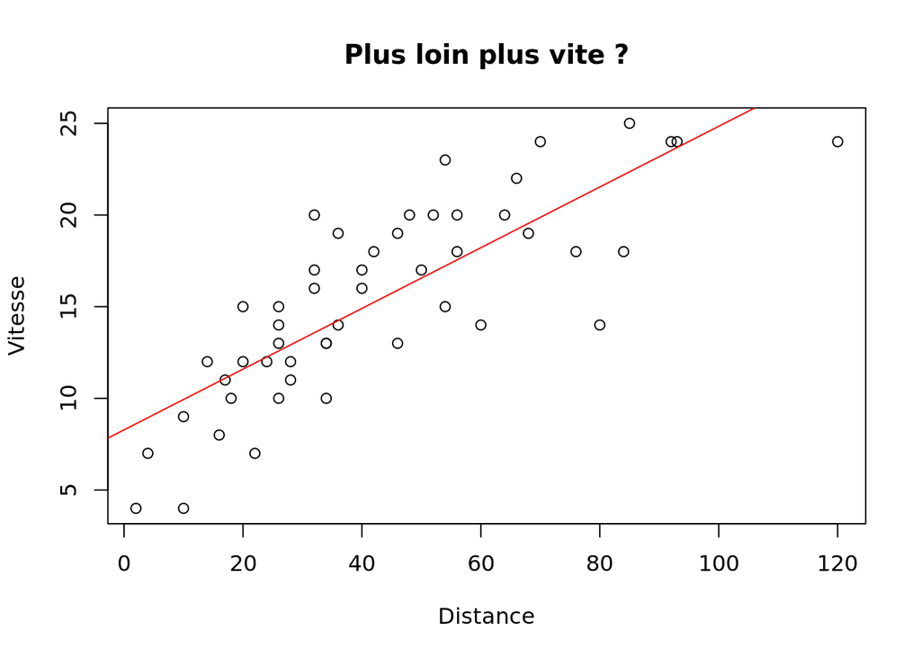

```r
plot(cars$dist,cars$speed,
     xlab = "Distance",ylab = "Vitesse",
     main="Plus loin plus vite ?")
abline(reg,col="red")
```

**test Anova d’independance :** Entre une variable quantitative et une variable qualitative

**Exemple :**

```r
df <- data.frame(quanti = 1:100, quali = c(rep("A",40),rep("B",60)))

# Deux méthodes

# On rejette l'hyphotèse d'idépendance
myaov= aov(quanti~quali,data=df)
summary(myaov)
```

```
##             Df Sum Sq Mean Sq F value Pr(>F)
## quali        1  60000   60000   252.1 <2e-16 ***
## Residuals   98  23325     238
## ---
## Signif. codes:  0 '***' 0.001 '**' 0.01 '*' 0.05 '.' 0.1 ' ' 1
```

```r
# Ou bien, On rejette l'hyphotèse d'idépendance
resultat = lm(quanti~quali,data=df)
anova(resultat)
```

```
## Analysis of Variance Table
##
## Response: quanti
##           Df Sum Sq Mean Sq F value    Pr(>F)
## quali      1  60000   60000  252.09 < 2.2e-16 ***
## Residuals 98  23325     238
## ---
## Signif. codes:  0 '***' 0.001 '**' 0.01 '*' 0.05 '.' 0.1 ' ' 1
```

**chisq.test(tab) :** Pour réaliser la statistique du Khi-deux sur un tableau de contingence

*X-squared* est la statistique du khi-deux *p-value* doit être suffisament faible pour rejeter l’hypothèse d’indépendance. *chisq.test(tab)$expected* Les valeurs théoriques du khi-deux

**Exemple :**

```r
  df <- data.frame(v1 = c(2,1,2,1,2), v2= c("A","B","A","A","B"), pond = 10:14 )
  tab <- tapply(df$pond, list(df$v1,df$v2), sum,default = 0)
  chisq.test(tab)
```

```
##
##  Pearson's Chi-squared test with Yates' continuity correction
##
## data:  tab
## X-squared = 0.071429, df = 1, p-value = 0.7893
```

```r
  #X-squared = 0.071429, df = 1, p-value = 0.7893
  # On ne rejette pas l'hypothèse d'indépendance des variables v1 et v2
  chisq.test(tab)$expected
```

```
##    A  B
## 1 14 10
## 2 21 15
```